# Laboratory Lab05 – Containers and Kubernetes

**Author: Bartłomiej Jamiołkowski**

In this Jupyter Notebook, I am presenting the solutions to the Assignments.

## Assignments

### Assignment 1

Dockerize AWS-CLI.

### a)

Creating a Dockerfile with aws-cli, built from source files (using tar.gz file / make).

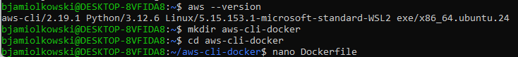

Using a multi-stage build and small base image, based on Alpine Linux, to create a small image. I used an [aws tutorial](https://docs.aws.amazon.com/cli/latest/userguide/getting-started-source-install.html). I improved dockerfile by having the groff installation removed and the Alpine version concretized.

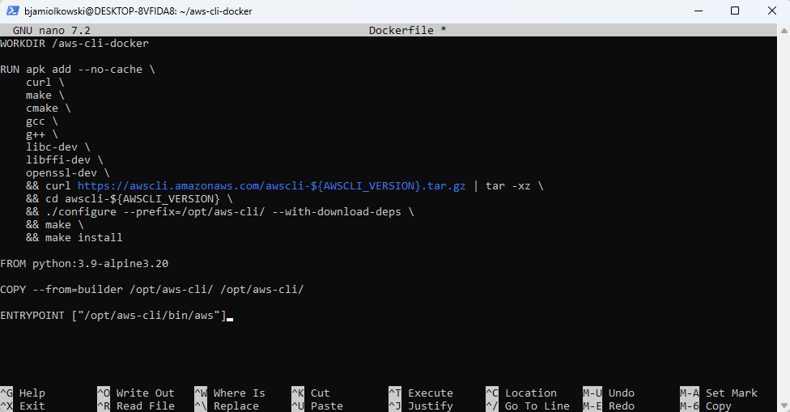

### b)

Building an image based on my Dockerfile.

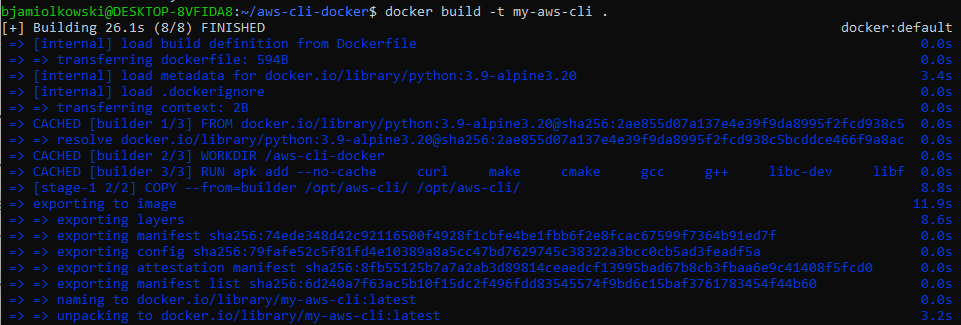

Checking the size of the container image.

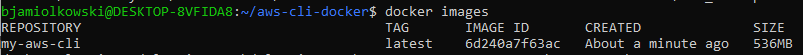

### Assignment 2

Kubernetes deployment.

### a)

Creating a k8s cluster using Amazon Elastic Kubernetes Service (EKS).

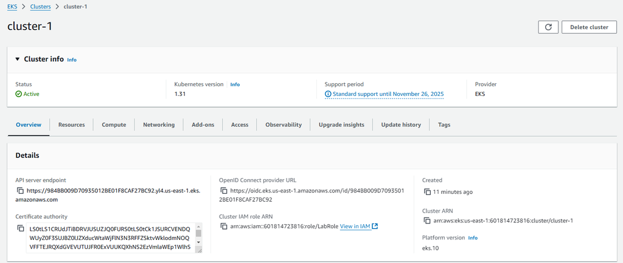

Creating node group for this cluster.

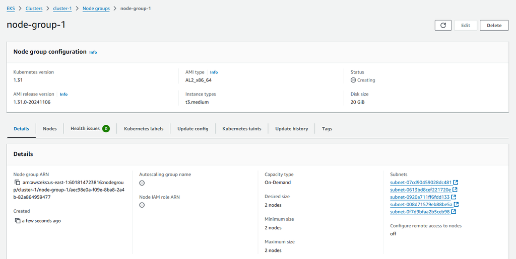

Cluster authentication.

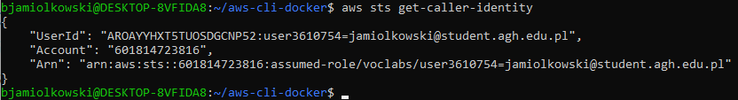

Testing configuration.

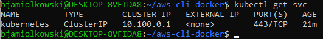

### b)

Using Helm, installing an NFS server and provisioner in the cluster.

Installing Helm.

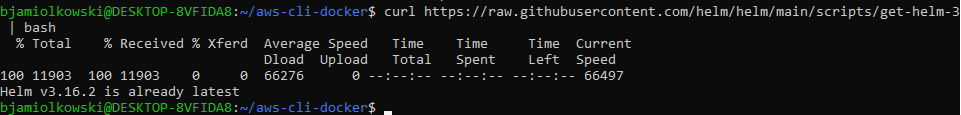

Installing nfs.

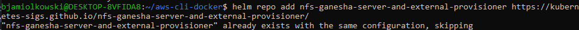

Changing StorageClass.

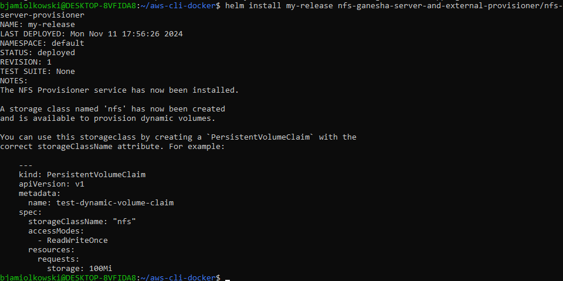

### c)

Creating a Persistent Volume Claim which will bind to a NFS Persistent Volume provisioned dynamically by the provisioner installed in the previous step.

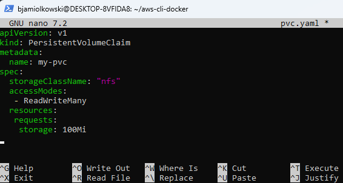

Checking pvc .

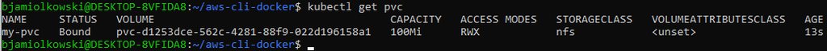

### d)

Creating a Deployment with a HTTP server (e.g., apache or nginx). The web content directory should be mounted as a volume using the PVC created in the previous step.

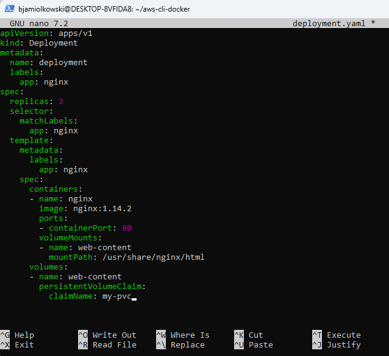

Running deployment.

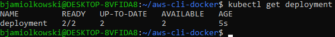

### e)

Creating a Service associated with the Pod(s) of the HTTP server Deployment.

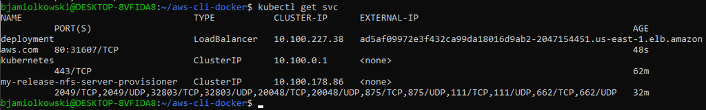

Checking details about svc.

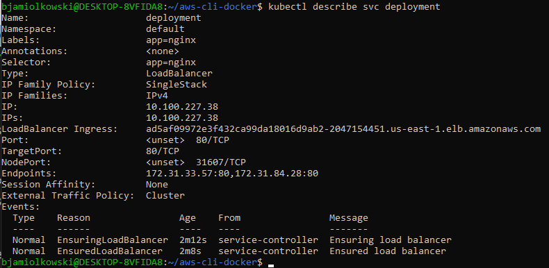

Checking details about nodes.

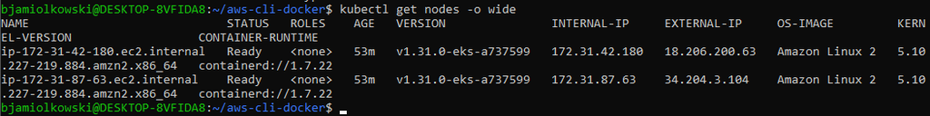

Checking security group rules.

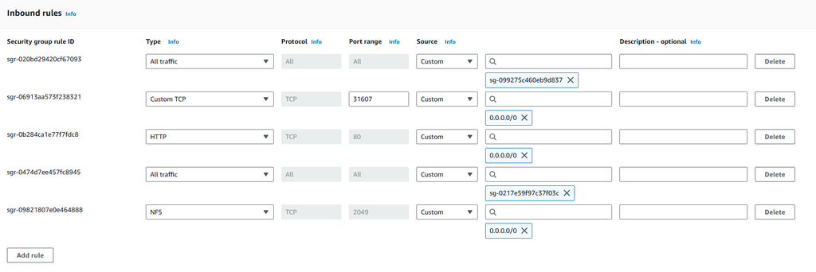

### f)

Creating a Job which mounts the PVC and copies a sample content through the shared NFS PV.

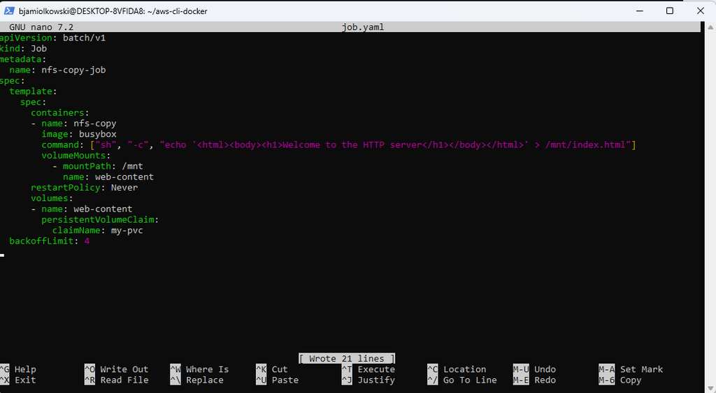

Checking if job is running.

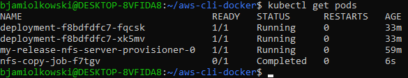

### g)

Testing the HTTP server by showing the sample web content in a browser.

Testing via WSL

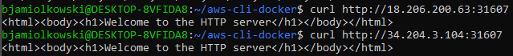

Testing via address bar.

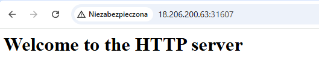

I would also like to add link to repo with this solved assignments. There are all created files and other documents: https://github.com/bjam24/agh-large-scale-computing